# Assignment 6

## 4

#### For one continuous + one categorical variables: Density and boxPlot

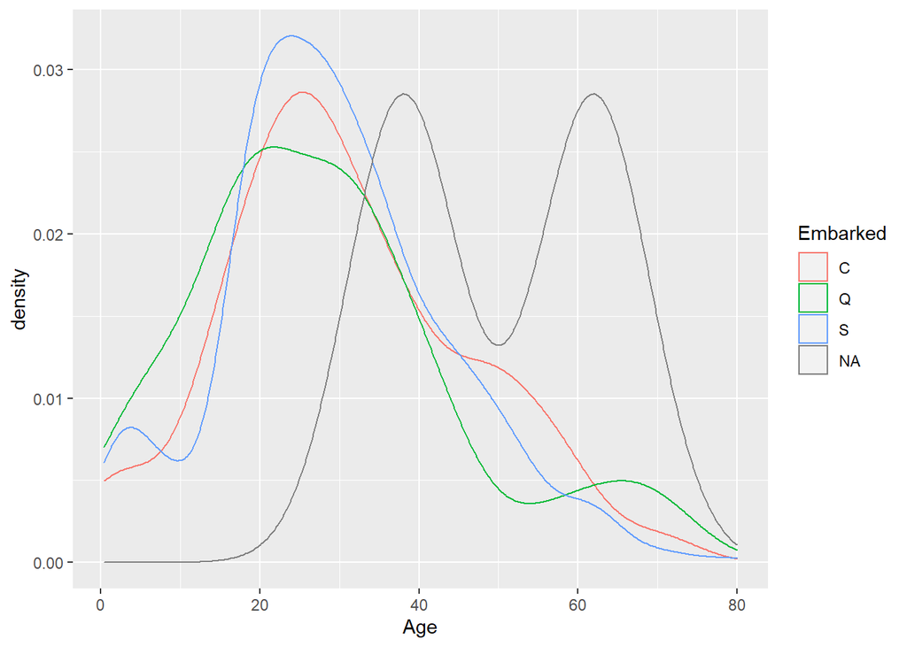

```r
#density
#the people that have NA's have higher ages
df %>% ggplot()+
  geom_density(mapping = aes(x = Age, color= Embarked))
```

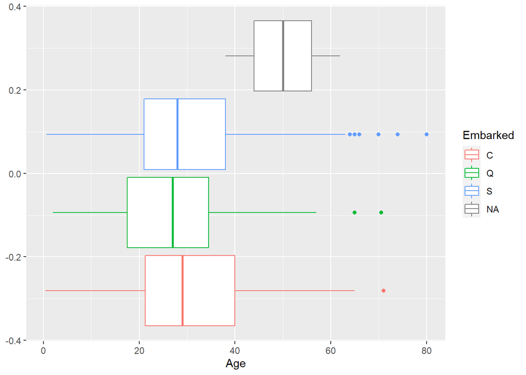

```r
# boxplot
#the people that have NA's have higher ages
df %>% ggplot()+
  geom_boxplot(mapping = aes(x = Age, color= Embarked))
```

## 5

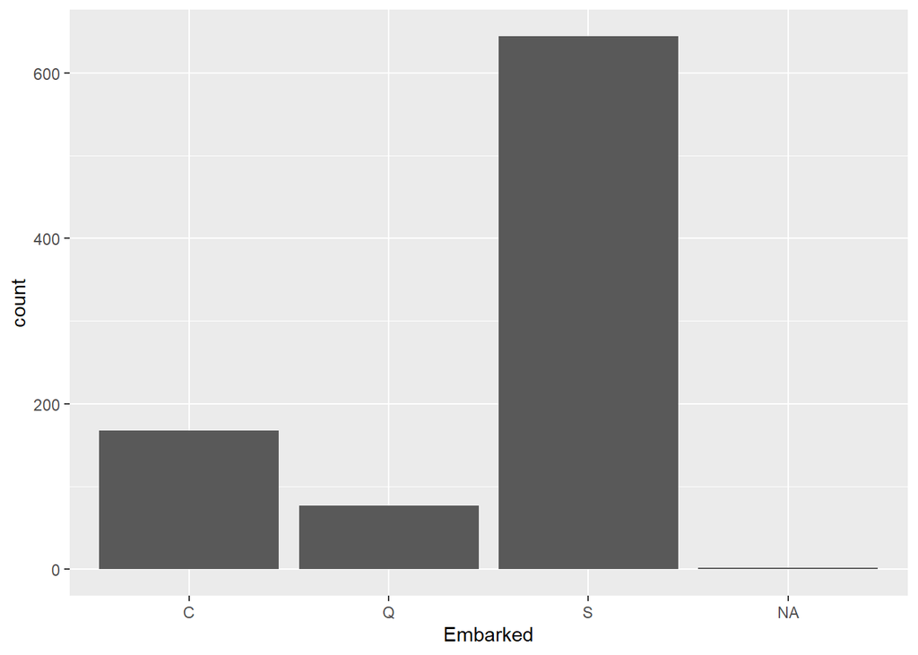

```r
df %>% ggplot()+
  geom_bar(mapping = aes(x = Embarked))
```

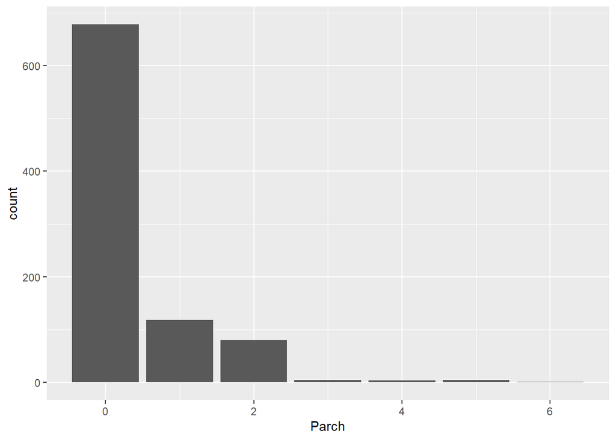

```r
df %>% ggplot()+
  geom_bar(mapping = aes(x = Parch))
```

# Questions on Covid Vaccination Data

## import the correct libaries

```r
library(tidyverse)
df <- read_csv('https://raw.githubusercontent.com/govex/COVID-19/master/data_tables/vaccine_data/us_data/time_series/vaccine_data_us_timeline.csv')
```

## 1

#### Geom_point makes scatter plots, which plot two numeric (or Date) variables. A third categorical variable is often brought in for color. For example, we can compare different vaccine types in Rhode Island by:

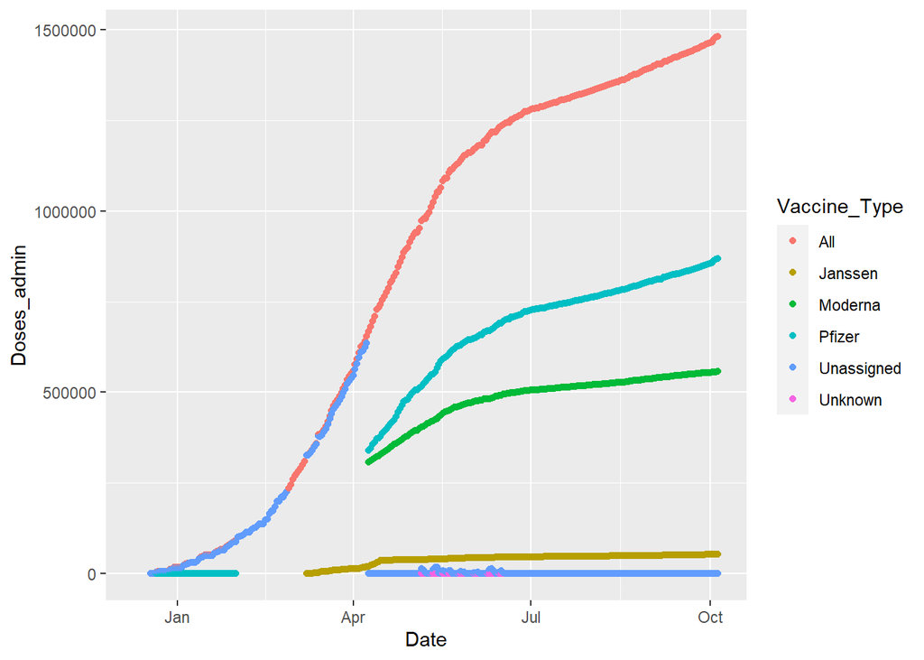

```r
df %>% filter(Province_State=='Rhode Island') %>% ggplot()+geom_point(mapping = aes(x = Date, y = Doses_admin, color = Vaccine_Type))
```

#### Do the following:

- Use geom_point to compare the the Moderna and Pfizer vaccine administered in California
- Use geom_point to compare the totall vaccine administered in Rhode Island and Massachusetts
- Change geom_point to geom_line in the above codes to have the corresponding line plots.

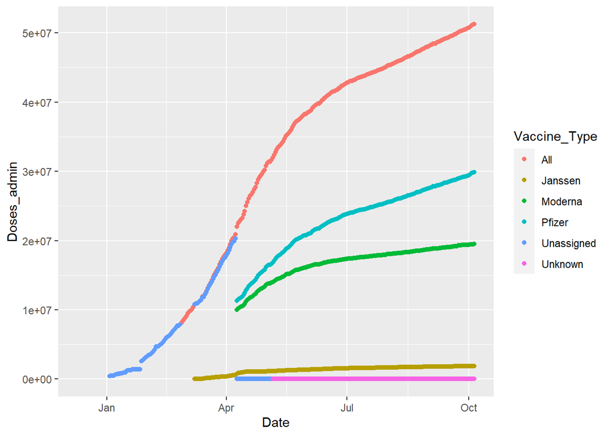

```r
#first bullet point
df %>% filter(Province_State=='California') %>% ggplot()+geom_point(mapping = aes(x = Date, y = Doses_admin, color = Vaccine_Type))
```

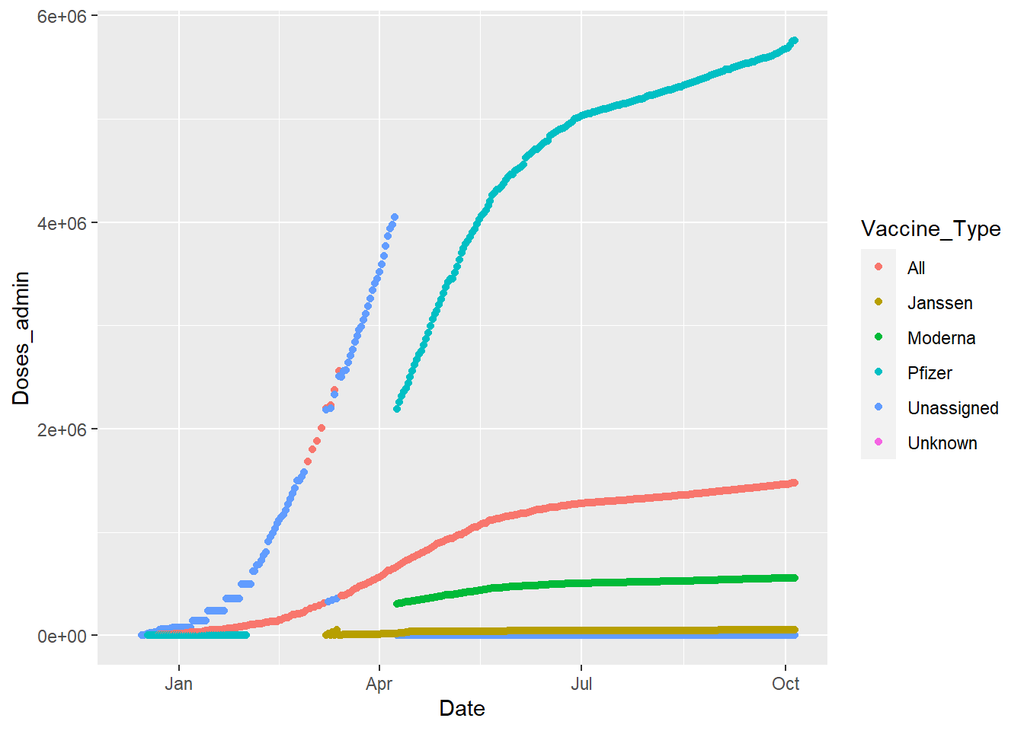

```r
#second bullet point
df %>% filter(Province_State==c('Rhode Island','Massachusetts')) %>% ggplot()+geom_point(mapping = aes(x = Date, y = Doses_admin, color = Vaccine_Type))
```

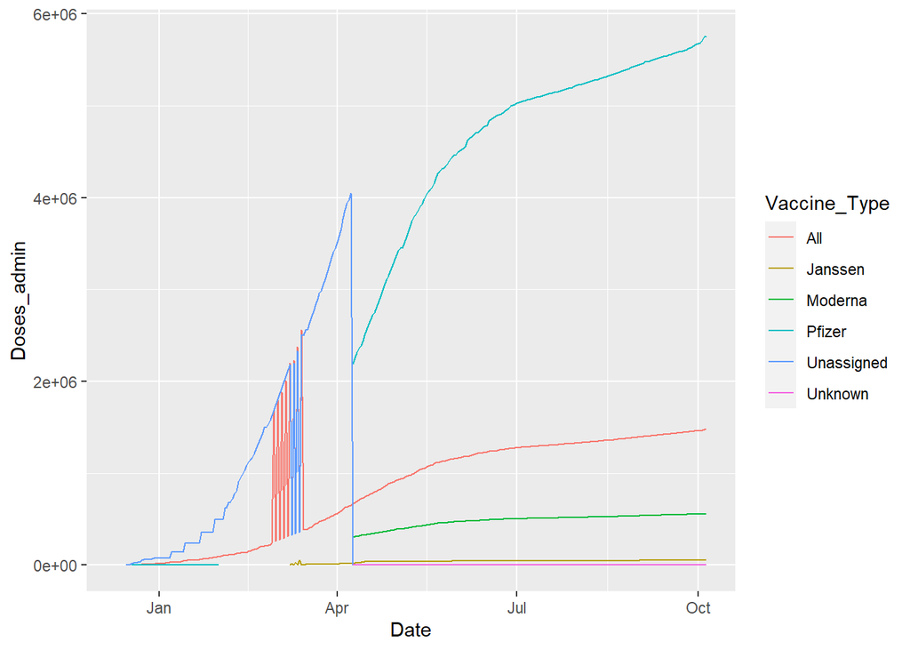

```r
#the bottom two is for the third
df %>% filter(Province_State==c('Rhode Island','Massachusetts')) %>% ggplot()+geom_line(mapping = aes(x = Date, y = Doses_admin, color = Vaccine_Type))
```

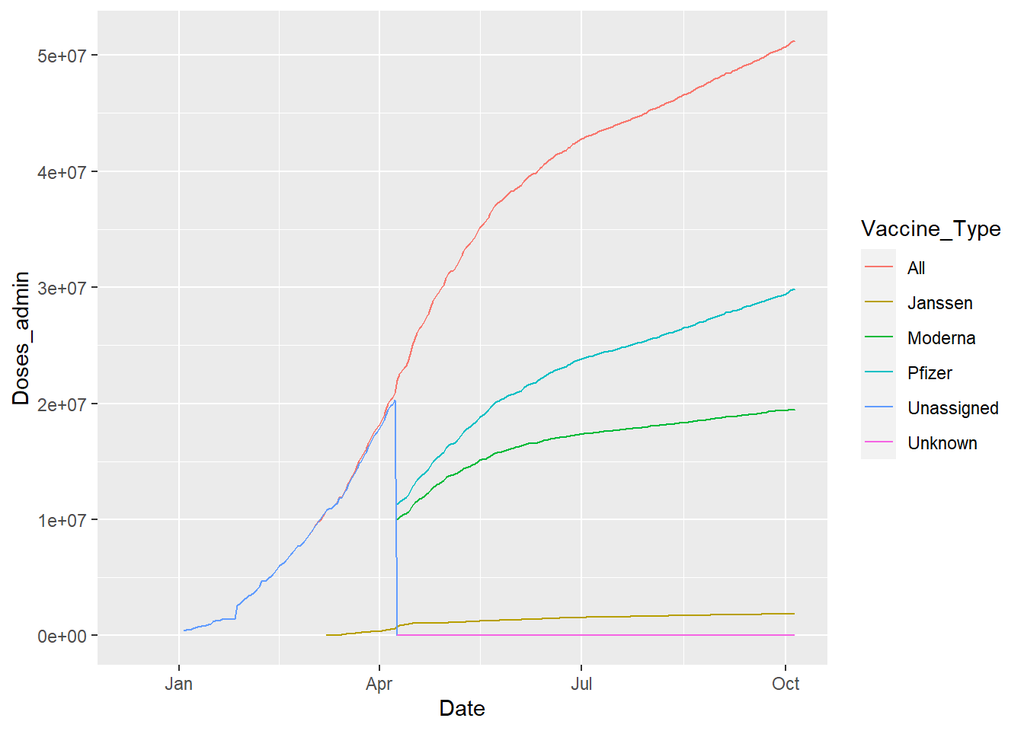

```r
df %>% filter(Province_State=='California') %>% ggplot()+geom_line(mapping = aes(x = Date, y = Doses_admin, color = Vaccine_Type))
```

## 2

#### Sometime we need to do some calculations on the data before plotting. For example, to compare the popularity of two vaccine Moderna and Pfizer by date, we can use.

```r
# Create a dataset recording these two vaccine administered by date
d1 <- df %>% filter(Vaccine_Type==c('Moderna','Pfizer')) %>% group_by(Date, Vaccine_Type) %>% summarise(vac_admin=mean(Doses_admin, na.rm=TRUE))
```

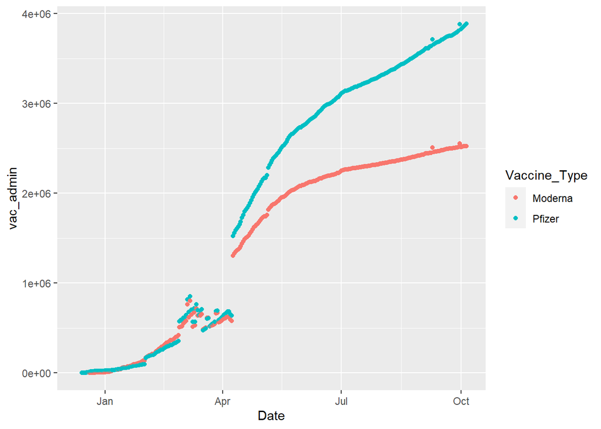

```r
# Plot from the newly create data
d1 %>% ggplot()+geom_point(mapping=aes(x=Date, y=vac_admin, color=Vaccine_Type))
```

#### Do the following:

- Use geom_point to compare the popularity of all vaccines by date.
- Use geom_line to compare the popularity of all vaccines in New England by date.
- Use geom_line to compare the popularity of all vaccines in New England by month.
- Use geom_line to compare states in New England in term of the total vaccine administered by date.
- Use geom_line to compare states in New England in term of the total vaccine administered by date.

```r
#first bullet
d2 <- df %>% group_by(Date, Vaccine_Type) %>% summarise(vac_admin=mean(Doses_admin, na.rm=TRUE))
```

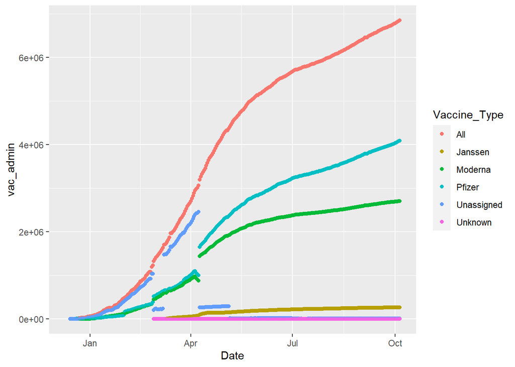

```r
d2 %>% ggplot()+geom_point(mapping = aes(x = Date, y = vac_admin, color = Vaccine_Type))
```

```r
#second bullet
d3 <- df %>% filter(Province_State==c('Rhode Island','Massachusetts','Vermont','Connecticut','New Hampshire', 'Maine')) %>% group_by(Date, Vaccine_Type) %>% summarise(vac_admin=mean(Doses_admin, na.rm=TRUE))
```

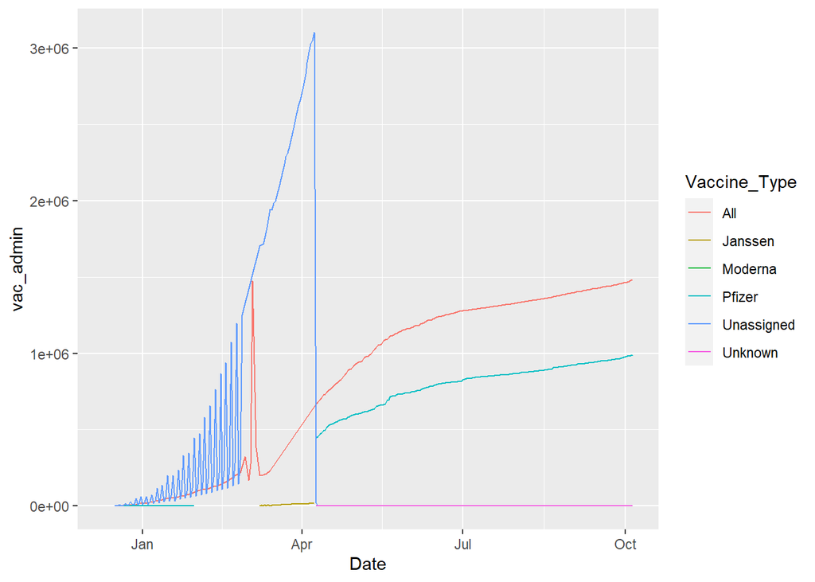

```r
d3 %>% ggplot()+geom_line(mapping = aes(x = Date, y = vac_admin, color = Vaccine_Type))
```

```r
#third bullet

#make a month column
library(lubridate)
df$Date <- ymd(df$Date)
df$month = month(df$Date)

d3 <- df %>% filter(Province_State==c('Rhode Island','Massachusetts','Vermont','Connecticut','New Hampshire', 'Maine'), Vaccine_Type==c('All')) %>% group_by(month, Vaccine_Type,Province_State) %>% summarise(vac_admin=mean(Doses_admin, na.rm=TRUE))
```

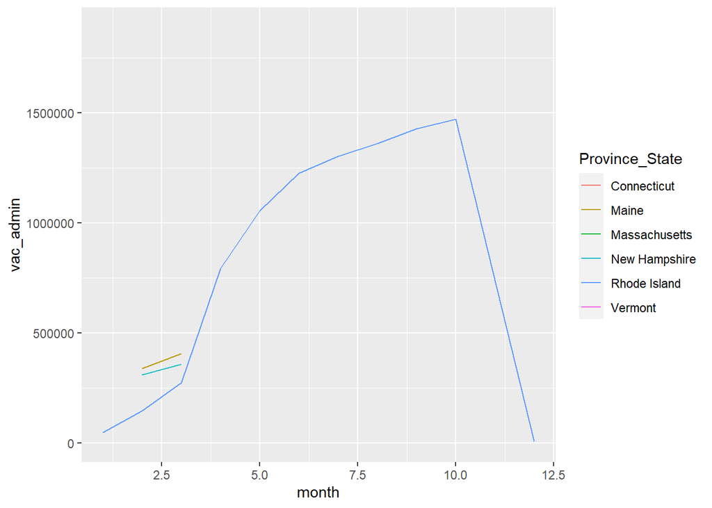

```r
d3 %>% ggplot()+geom_line(mapping = aes(x = month, y = vac_admin,color = Province_State))
```

```r
#forth bullet point

d4 <- df %>% filter(Province_State==c('Rhode Island','Massachusetts','Vermont','Connecticut','New Hampshire', 'Maine'),Vaccine_Type==c('All')) %>% group_by(Date, Vaccine_Type) %>% summarise(vac_admin=mean(Doses_admin, na.rm=TRUE))
```

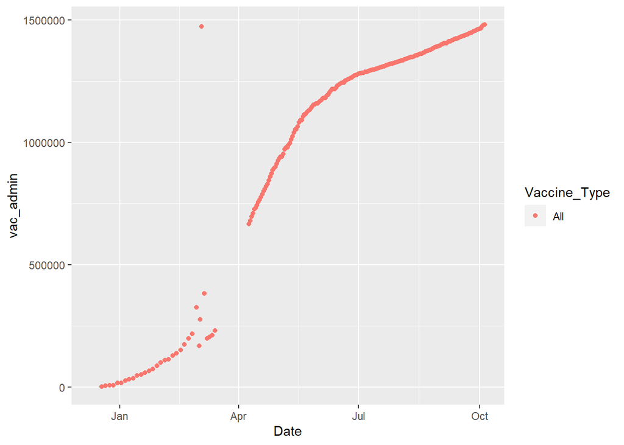

```r
d4 %>% ggplot()+geom_point(mapping = aes(x = Date, y = vac_admin, color = Vaccine_Type))
```